# Reproducible Research: Peer Assessment 1

## Loading and preprocessing the data

### 1. Load the data (i.e. read.csv())

```r
setwd("/Users/rong/Dropbox/code/GitHub/Coursera/Data Science/Reproduce Data/PA/RepData_PeerAssessment1")
data_raw=read.csv("./activity.csv", na.strings="?",colClasses=c("numeric","character","numeric"))
```

### 2. Process/transform the data (if necessary) into a format suitable for your analysis

```r
data_raw$date <- strptime(data_raw$date, "%Y-%m-%d")
data<-data_raw[!is.na(data_raw$steps),]
head(data_raw)
```

```
##   steps       date interval
## 1    NA 2012-10-01        0
## 2    NA 2012-10-01        5
## 3    NA 2012-10-01       10
## 4    NA 2012-10-01       15
## 5    NA 2012-10-01       20
## 6    NA 2012-10-01       25
```

## What is mean total number of steps taken per day?

### 1. Make a histogram of the total number of steps taken each day

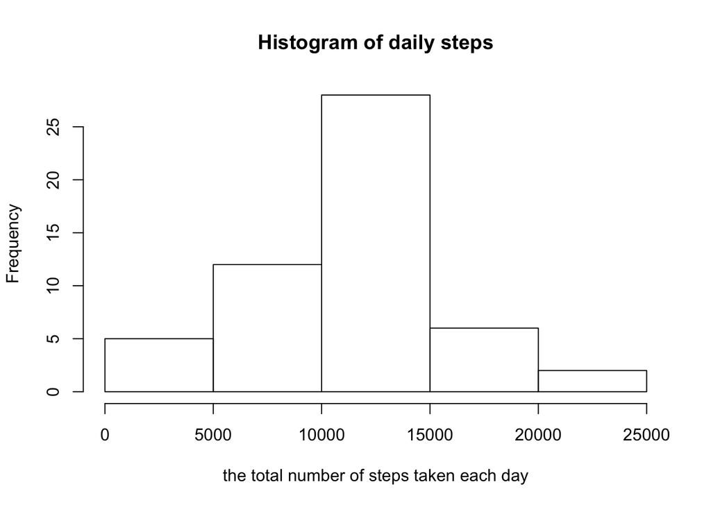

```r
library(plyr)
daily_step<-ddply(data,.(date), summarise, steps=sum(steps))
# png(filename="figure/1.png")
hist(daily_step$steps,main="Histogram of daily steps", xlab="the total number of steps taken each day")
```

```r
# dev.off()
```

### 2. Calculate and report the mean and median total number of steps taken per day

```r
# the mean and median total number of steps taken per day
mean(daily_step$steps)
```

```
## [1] 10766.19
```

```r
median(daily_step$steps)
```

```
## [1] 10765
```

## What is the average daily activity pattern?

### 1. Make a time series plot (i.e. type = “l”) of the 5-minute interval (x-axis) and the average number of steps taken, averaged across all days (y-axis)

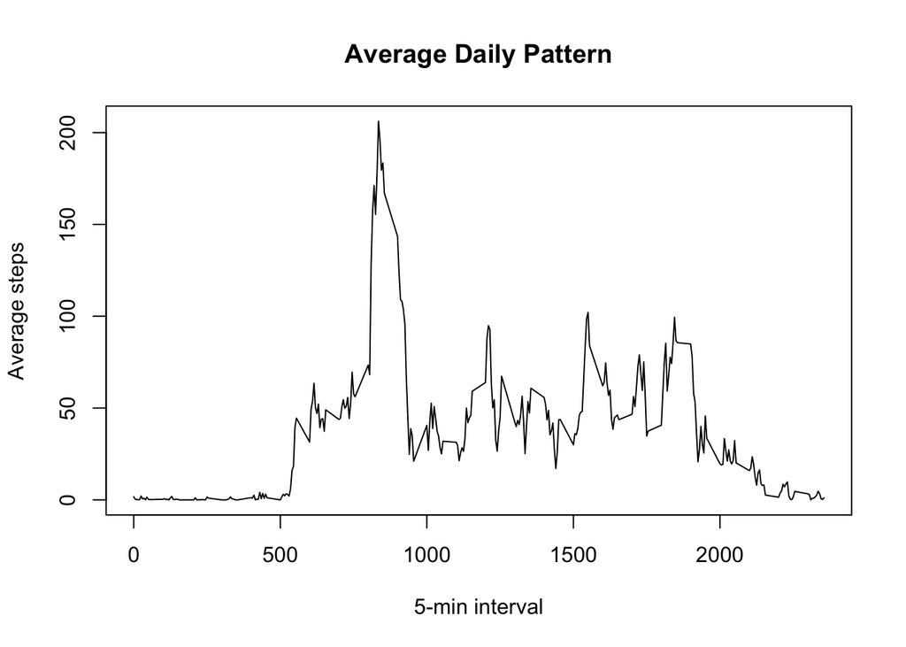

```r
# Make a time series plot (i.e. type = "l") of the 5-minute interval (x-axis) and the average number of steps taken, averaged across all days (y-axis)

daily_pattern <- ddply(data, .(interval), summarise, avgsteps = mean(steps))
# png(filename="figure/2.png")
plot(daily_pattern$interval, daily_pattern$avgsteps, type="l", xlab="5-min interval", ylab="Average steps", main="Average Daily Pattern")
```

```r
# dev.off()
```

### 2. Which 5-minute interval, on average across all the days in the dataset, contains the maximum number of steps?

```r
# Which 5-minute interval, on average across all the days in the dataset, contains the maximum number of steps?

daily_pattern[daily_pattern$avgsteps==max(daily_pattern$avgsteps),]
```

```
##     interval avgsteps
## 104      835 206.1698
```